# Villanova Basketball Analytics

By Kevin O’Donnell

# Summary

This report will cover a variety of questions surrounding Villanova basketball that I have asked and answered with statistical inference, plots, and probability models. I have segmented the article into 2 main sections, corresponding to the season in which I am performing these analyses. I begin with a short analysis of the Villanova vs Georgetown game from the current season (2020-2021), because I think it is the most exciting game thus far. After that, I investigate clutch shooting for Villanova’s players in both the 2020-2021 and 2019-2020 seasons and then model the starters’ shooting streaks from 2019-2020 to see if any of them have a hot hand or not.

# Loading packages

Main package: ncaahoopR by Luke Benz (lbenz730)

```r
library("devtools")
devtools::install_github("lbenz730/ncaahoopR")
library("ncaahoopR")
library(pacman)
pacman::p_load(dplyr, ggplot2, dbplyr, statsr, gridExtra)
```

# 2020-2021 Season

```r
get_schedule("Villanova")
```

```
##      game_id       date       opponent location team_score opp_score    record
## 1  401260006 2020-11-25 Boston College        N         76        67 1-0 (0-0)
## 2  401260008 2020-11-26  Arizona State        N         83        74 2-0 (0-0)
## 3  401255593 2020-11-28  Virginia Tech        N         73        81 2-1 (0-0)
## 4  401266133 2020-12-01       Hartford        N         87        53 3-1 (0-0)
## 5  401259857 2020-12-06          Texas        A         68        64 4-1 (0-0)
## 6  401254978 2020-12-11     Georgetown        A         76        63 5-1 (1-0)
## 7  401254987 2020-12-16         Butler        H         85        66 6-1 (2-0)
## 8  401270594 2020-12-19 Saint Joseph's        H         88        68 7-1 (2-0)
## 9  401255019 2020-12-23      Marquette        A         85        68 8-1 (3-0)
## 10 401269611 2021-01-15          UConn        A         NA        NA       FS1
## 11 401269617 2021-01-19     Seton Hall        H         NA        NA       FS1
## 12 401269624 2021-01-23     Providence        H         NA        NA
## 13 401269633 2021-01-30     Seton Hall        A         NA        NA
## 14 401269638 2021-02-03     St. John's        A         NA        NA     CBSSN
## 15 401269643 2021-02-07         Xavier        H         NA        NA
## 16 401272043 2021-02-09         DePaul        H         NA        NA
## 17 401269644 2021-02-13      Creighton        A         NA        NA
## 18 401269652 2021-02-17     Georgetown        H         NA        NA     CBSSN
## 19 401269655 2021-02-20          UConn        H         NA        NA       FOX
## 20 401272048 2021-02-23     St. John's        H         NA        NA
## 21 401269661 2021-02-28         Butler        A         NA        NA       CBS
## 22 401269666 2021-03-03      Creighton        H         NA        NA       FS1
## 23 401269667 2021-03-06     Providence        A         NA        NA
```

```r
nova_game_IDs <- get_game_ids("Villanova", "2020-2021")
```

Creating a dataframe to hold every play from the 2020-2021 season thus far.

```r
Full_szn_pbp <- get_pbp("Villanova", "2020-2021")
```

## Basic Figures and Plots for Villanova vs Georgetown

Saving the Georgetown play-by-play data + producing win probability chart and game excitement index.

```r
Gtown_pbp <- get_pbp_game(401254978)
```

```
## Scraping Data for Game: 1 of 1
```

```
## Getting Shots for Game 1 of 1
```

```
## No shot location data available for this game.
```

```
## Parsing Possessions
```

```
## Scraping Data for Game: 1 of 1
```

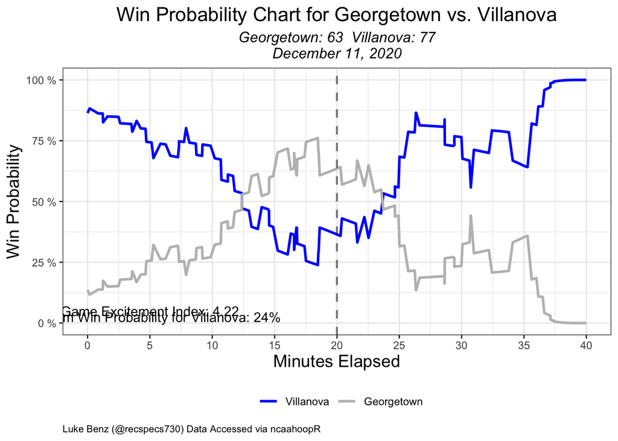

```r
gg_wp_chart(401254978, "grey", "blue")
```

```r
GEI_Nova_Gtown <- game_excitement_index(401254978, include_spread = T)
```

```
## Scraping Data for Game: 1 of 1
```

```r
cat("Game Excitement Index: ", GEI_Nova_Gtown)
```

```
## Game Excitement Index:  4.217617
```

According to Luke Benz, the game excitement index (GEI) attempts to quantify how exciting a game was to watch. The distribution of GEI is right skewed, meaning there are more boring or moderately exciting games of than extremely exciting games. This makes sense because for something to be deemed “exciting” it should be out of the ordinary. The average GEI is 3.6. This Villanova vs. Georgetown game comes in at around 4.2, so it slightly more exciting than the average game in terms of neutral fan enjoyment. The reason for this is likely because Georgetown, despite being the underdog, was up 18 in the first half. Villanova managed to overcome this deficit, rather remarkably, and win the game by 14.

## Who is the best clutch shooter on Villanova’s team this season?

My goal here is to calculate each players’ shooting percentage in crunch time to see who performs the best offensively under pressure. Obviously there are numerous other factors that determine how someone performs in the clutch, like turnovers, rebounds, and assists, and even qualitative variables, like positioning on the floor and communication. In this example, I chose to rank each player on the roster by shooting percentage because that shows how well they are converting their scoring chances.

Subset full season to just 2 minutes left with score within 2 possessions. These are the plays during crunch time Creating variables to calculate clutch/crunch time FG%

```r
clutch <- Full_szn_pbp %>%
  select(secs_remaining, score_diff, shot_team, shot_outcome, shooter) %>%
  filter(secs_remaining <= 120, abs(score_diff) <= 6, shot_team=="Villanova") %>%
  group_by(shot_team, shooter) %>%
  arrange(shooter) %>%
  mutate(num_outcome = ifelse(shot_outcome=="made", 1, 0)) %>%
  mutate(n=n()) %>%
  mutate(makes=sum(num_outcome)) %>%
  mutate(clutch_percentage = makes/n)
```

Summarizing and plotting clutch FG% for each player

```r
clutch_summary <- clutch[!duplicated(clutch$shooter), ] %>%
  select(shooter, clutch_percentage, n) %>%
  arrange(desc(clutch_percentage))
```

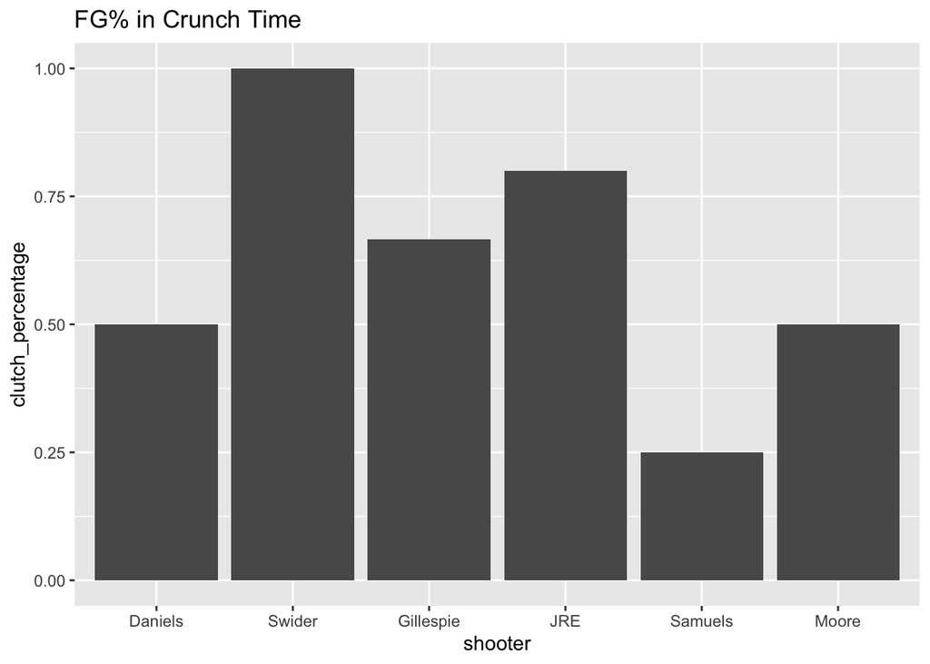

```r
View(clutch_summary)

ggplot(clutch_summary, aes(x=shooter, y=clutch_percentage)) +
  geom_bar(stat = "identity", position = position_dodge()) +
  labs(title = "FG% in Crunch Time") +
  scale_x_discrete(breaks=c("Caleb Daniels", "Cole Swider", "Collin Gillespie", "Jeremiah Robinson-Earl", "Jermaine Samuels", "Justin Moore"),
                   labels=c("Daniels", "Swider", "Gillespie", "JRE", "Samuels", "Moore"))
```

Currently, these results do not mean much because of the small sample size. Collin Gillespie, who has taken the most shots during crunch time, has only 6 recorded shots thus far. Cole Swider, despite having a perfect clutch percentage, is only 1/1, so we cannot determine who is the most clutch at this point in the season. However, as the season progresses, we can produce the same plot with more data and yield more confident results. To correct for the small sample size, I performed the same operations on last season’s data. Given that many players are returning from last year’s squad, we will be able to see who we can trust in crunch time this year.

# 2019-2020 Season

## Who was the best clutch shooter on Villanova’s team last season?

I am repeating the process above to determine last season’s best performers in crunch time. This season has much more data, since we are just beginning the 2020-2021 season, so it should yield more dependable results.

```r
get_schedule("Villanova")
nova_game_IDs_2019 <- get_game_ids("Villanova", "2019-2020")

Full_szn_pbp_2019 <- get_pbp("Villanova", "2019-2020")

clutch_2019 <- Full_szn_pbp_2019 %>%
  select(secs_remaining, score_diff, shot_team, shot_outcome, shooter) %>%
  filter(secs_remaining <= 120, abs(score_diff) <= 6, shot_team=="Villanova") %>%
  group_by(shot_team, shooter) %>%
  arrange(shooter) %>%
  mutate(num_outcome = ifelse(shot_outcome=="made", 1, 0)) %>%
  mutate(n=n()) %>%
  mutate(makes=sum(num_outcome)) %>%
  mutate(clutch_percentage = makes/n)

clutch_summary_2019 <- clutch_2019[!duplicated(clutch_2019$shooter), ] %>%
  select(shooter, clutch_percentage, n, makes) %>%
  arrange(desc(clutch_percentage))
```

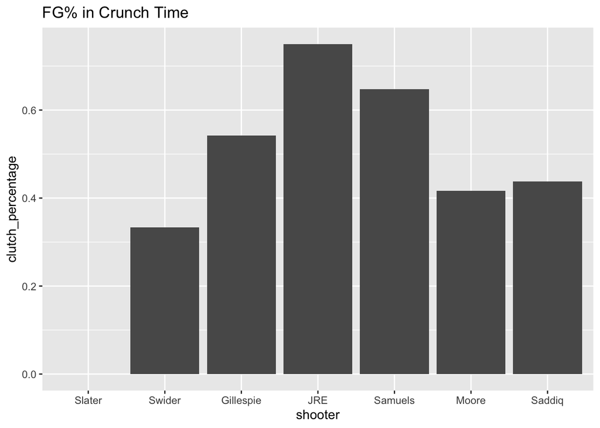

```r
ggplot(clutch_summary_2019, aes(x=shooter, y=clutch_percentage)) +
  geom_bar(stat = "identity", position = position_dodge()) +
  labs(title = "FG% in Crunch Time") +
  scale_x_discrete(breaks=c("Brandon Slater", "Cole Swider", "Collin Gillespie", "Jeremiah Robinson-Earl", "Jermaine Samuels", "Justin Moore", "Saddiq Bey"),
                   labels=c("Slater", "Swider", "Gillespie", "JRE", "Samuels", "Moore", "Saddiq"))
```

In the 2019-2020 season, Jeremiah Robinson-Earl had the highest shooting percentage in crunch time at 75%. Gillespie and Samuels also look like solid options in the clutch, with shooting percentages above 50% and 60% respectively. Robinson-Earl may have a higher clutch FG% because he tends to take higher percentage shots, given his position (PF/C). He is likely to take more shots close to the basket than Gillespie, for example, who shoots many of his shots from 3 point range. Gillespie would probably be the go to for a clutch 3 pointer, since his 3 point percentage was 35.7% last year, higher than Robinson-Earl and Samuels. However, it appears that all 3 would be solid options overall, given that each of their clutch FG% are above 50% and higher than their season averages.

The disparity between clutch and overall FG% could be due to small sample size, because each player took 24 or fewer shots in the clutch last season, so these results should be trusted tentatively. If everyone took more shots, perhaps their clutch percentages would fall closer to their season averages. Additionally, the apparent difference between these 2 percentages could not exist at all. In order to test if the difference in these 2 proportions is 0 or not, I will perform a 2 proportion t-test and create a 95% confidence interval for the difference.

```r
fg_2019 <- Full_szn_pbp_2019 %>%
  select(secs_remaining, score_diff, shot_team, shot_outcome, shooter) %>%
  filter(shot_team=="Villanova") %>%
  group_by(shot_team, shooter) %>%
  arrange(shooter) %>%
  mutate(num_outcome = ifelse(shot_outcome=="made", 1, 0)) %>%
  mutate(tn=n()) %>%
  mutate(tmakes=sum(num_outcome)) %>%
  mutate(fg_percentage = tmakes/tn)

fg_summary_2019 <- fg_2019[!duplicated(fg_2019$shooter), ] %>%
  select(shooter, fg_percentage, tmakes, tn) %>%
  filter(shooter %in% c("Jeremiah Robinson-Earl", "Jermaine Samuels", "Collin Gillespie", "Brandon Slater", "Cole Swider", "Saddiq Bey", "Justin Moore")) %>%
  arrange(desc(shooter))
all_makes <- merge(fg_summary_2019, clutch_summary_2019) %>%
  select(tmakes, makes)
all_n <- merge(fg_summary_2019, clutch_summary_2019) %>%
  select(tn, n)


x <- as.numeric(as.vector(all_makes[5,]))
n <- as.numeric(as.vector(all_n[5,]))

print("Comparing Jermaine Samuels' Season and Clutch FG%")
```

```
## [1] "Comparing Jermaine Samuels' Season and Clutch FG%"
```

```r
prop.test(x, n, p = NULL, alternative = "two.sided",
          correct = TRUE)
```

```
##
##  2-sample test for equality of proportions with continuity correction
##
## data:  x out of n
## X-squared = 0.35976, df = 1, p-value = 0.5486
## alternative hypothesis: two.sided
## 95 percent confidence interval:
##  -0.3694188  0.1591335
## sample estimates:
##    prop 1    prop 2
## 0.5419162 0.6470588
```

In the code above I have subset the full season data in the same way that I did the clutch data. Likewise, I am adding variables for each player’s total makes and total shots, to compare with their clutch makes and clutch shots from the previous analysis. I am creating a summary table for the 2019 season and merging it with the clutch summary table from that season, which I created previously. Using the two merged tables (one for shots and one for makes), I can run a proportion test to compare each player’s season and clutch FG%. The results shown are for Jermaine Samuels, but the analysis can be run for every player in the merged table with a small adjustment to the x and n variables. In the example above, we can see a p-value and a confidence interval for the difference in proportions. If the p-value is less than 0.05 or 0 is not included in the confidence interval, we can conclude that there is a difference in the given player’s season and clutch shooting percentages.

For every player listed there is no difference between season and clutch FG% (except for Brandon Slater, who, along with Cole Swider, does not have a large enough number of shots in crunch time to evaluate). Although there appeared to be a large difference for players with high clutch percentages, like JRE and Jermaine Samuels, the proportion tests and confidence intervals reveal that we cannot reject the null hypothesis that there is no difference. In other words, there is not sufficient evidence to suggest that any of the listed players perform better in crunch time than they do overall.

As a result, the high shooting percentages above may indicate that certain players, like JRE, Samuels, and Gillespie, perform well in the clutch in general, but they do not excel compared to their traditional shooting percentages. These players do not become significantly better in crunch time, so by their standards their clutch performances are not out of the ordinary. That being said, each of these 3 players are able to shoot very efficiently in crunch time, so Villanova can depend on them. None of these 3 players exhibit regressions in their shooting percentages during big moments. While their percentages may not increase, they stay relatively stable, suggesting JRE, Samuels, and Gillespie can all perform offensively when Villanova needs them to.

## Do Any 2020-2021 Starters Have a Hot Hand?

I want to see if any of Villanova’s current starters go on longer shooting runs than they would if their shooting percentages were independent of any shot they took before. In other words, do any of the starters get hot and improve their shooting percentage as they make more shots? I will be using last season’s data so I have enough observations for each player.

Creating a dataframe for only Gillespie’s shots from the 2019-2020 season

```r
Collin_shots <- Full_szn_pbp_2019 %>%
  select(shooter, shot_outcome, game_id) %>%
  mutate(hit_miss = ifelse(shot_outcome=="made", "H", "M")) %>%
  filter(shooter=="Collin Gillespie") %>%
  group_by(game_id)
```

Calculating Gillespie’s shooting streaks from last season and plotting their distribution

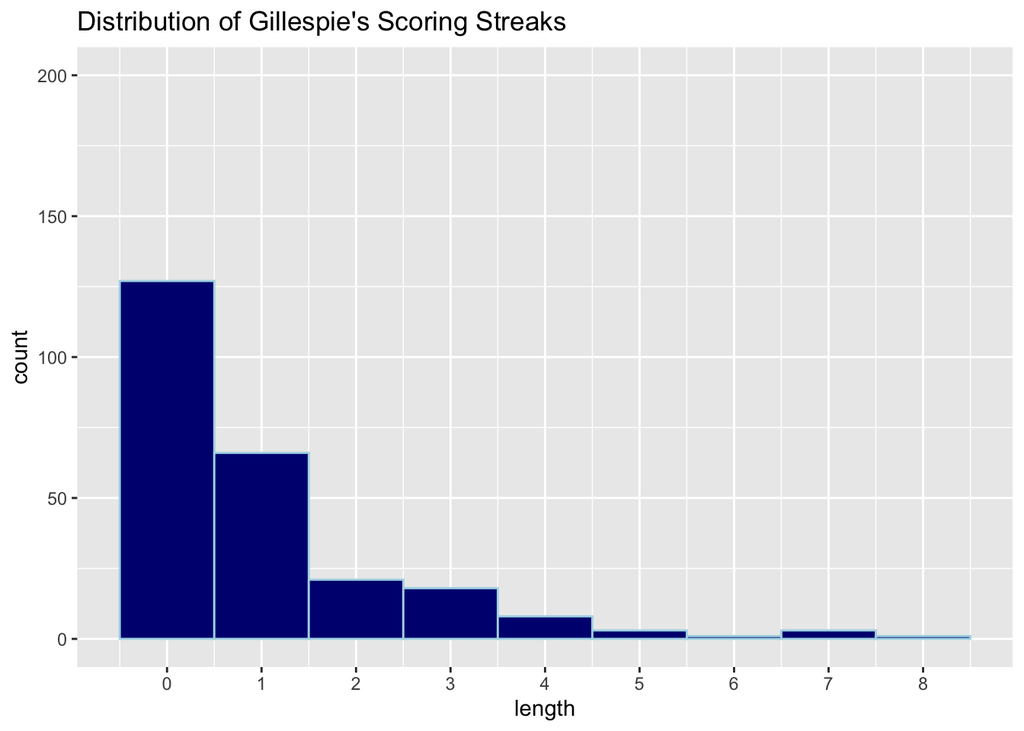

```r
collin_streak <- calc_streak(Collin_shots$hit_miss)
ggplot(data=collin_streak, aes(x = length)) +
  geom_histogram(binwidth = 1, color="lightblue", fill="navy") +
  scale_x_continuous(breaks=c(0, 1, 2, 3, 4, 5, 6,7, 8)) +
  labs(title = "Distribution of Gillespie's Scoring Streaks") +
  scale_y_continuous(limits = c(0, 200))
```

Random shooting streak with Gillespie’s FG% and attempts. These are the shooting streaks Collin would have if every one of his shots were independent of the others.

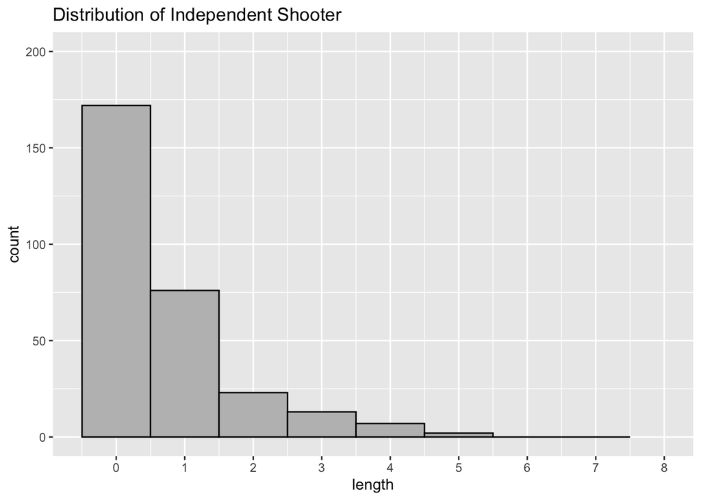

```r
shot_outcomes <- c("H", "M")
sim_basket <- sample(shot_outcomes, size = 491, replace = T, prob = c(0.406, 0.594))
sim_streak <- calc_streak(sim_basket)
ggplot(sim_streak, aes(x=length)) +
  geom_histogram(binwidth = 1, color="black", fill="grey") +
  scale_x_continuous(breaks=c(0, 1, 2, 3, 4, 5, 6, 7, 8) , limits = c(-0.5,8)) +
  labs(title = "Distribution of Independent Shooter") +
  scale_y_continuous(limits = c(0, 200))
```

Gillespie’s streak distribution appears to be similar to that of the independent sample, which would suggest that Gillespie does not have a hot hand. Since the distributions are similar, Gillespie’s shooting percentage should be independent of his shooting performance in any given game.

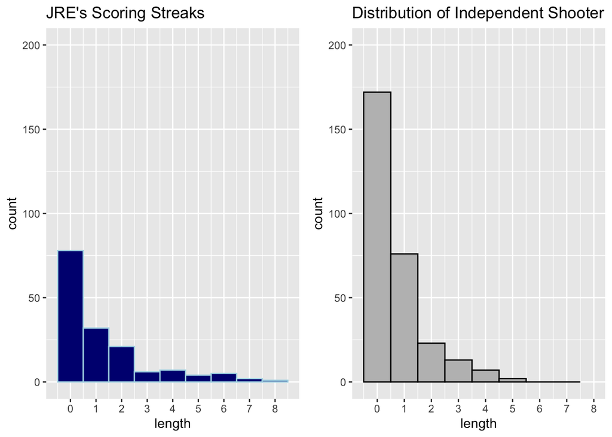

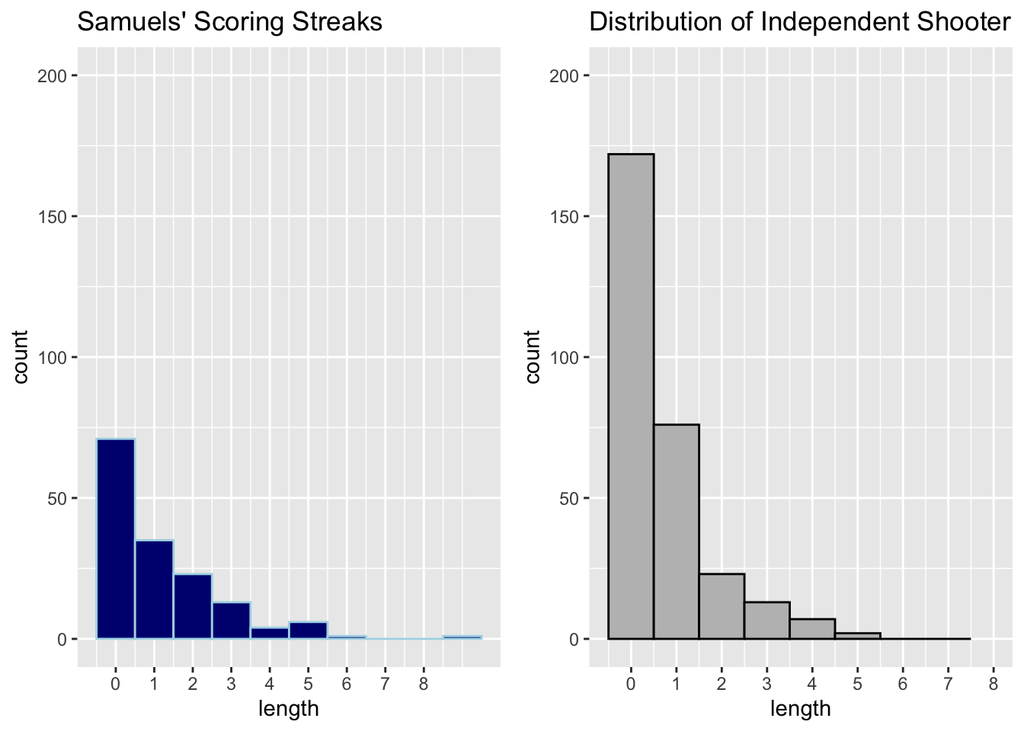

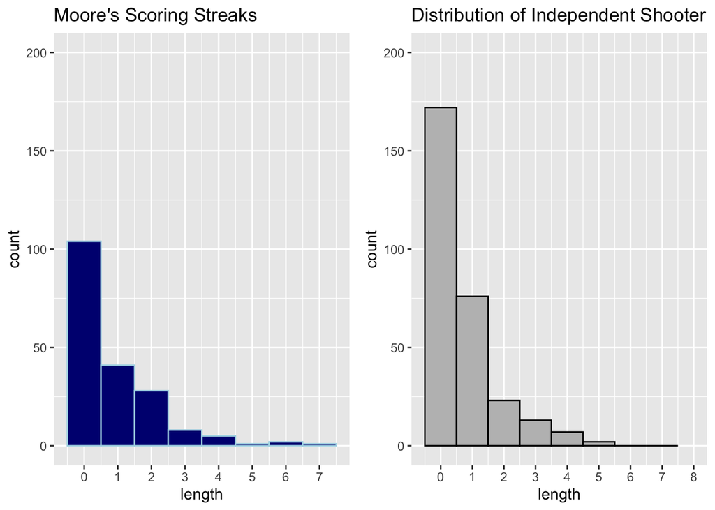

I am more inclined to say that none of them do because none of the distributions differ drastically in terms of shape or skewness when compared to their independent model. Each player’s streak distributions are heavily right skewed, like the independent models, and the counts for each streak length are not different enough to be notable, especially when you consider that every starter follows a similar pattern.

In conclusion, although each starter has slightly more long shooting streaks and slightly fewer short streaks, none of them have a convincingly hot hand. Their shooting percentage stays relatively stable no matter their in game performance, so there is not a need to focus Villanova’s offense on one player if he begins to go on a personal run. Given Villanova’s emphasis on spreading the ball around, the lack of hot hands should not have a negative impact on performance. In fact, it allows the team to keep a consistent offense and keep the defense guessing about who the ball will go to.